# LAB 7: Machine Learning using the Scikit-learn and the MNIST dataset

## 2. Experiments with Logistic Regression Classifier

### **Step 1.**

For this section, we need to use logistic regression classifier to train and test the standard test mnist dataset and the dataset we created. The below code is to realize this goal. First, we download the mnist dataset and use them to train the logistic regression model. Then, output the first forty test images and their labels as well as their predicted results.

```python
#1 import required modules
import time
import io
import matplotlib.pyplot as plt
import numpy as np
from scipy.io.arff import loadarff

from sklearn.datasets import get_data_home
from sklearn.externals.joblib import Memory
from sklearn.linear_model import LogisticRegression
from sklearn.model_selection import train_test_split
from sklearn.preprocessing import StandardScaler
from sklearn.utils import check_random_state
from urllib.request import urlopen
```

```python
#2.  read the NMIST dataset
memory = Memory(get_data_home())
@memory.cache()
def fetch_mnist():
    content = urlopen(
        'https://www.openml.org/data/download/52667/mnist_784.arff').read()
    data, meta = loadarff(io.StringIO(content.decode('utf8')))
    data = data.view([('pixels', '<f8', 784), ('class', '|S1')])
    return data['pixels'], data['class']
X, y = fetch_mnist()
```

```python
#3 rescale the data, use the traditional train/test split
X = X / 255.
# NEW  Refromat the the labels to be integers rather than byte arrays
y_trans = []
for i in range(len(y)):
    y_trans.append(int(y[i]))
y = np.asarray(y_trans)

X_train, X_test = X[:60000], X[60000:]
y_train, y_test = y[:60000], y[60000:]
```

**Comment:**

This is a good point and we need to convert the byte format of y into int format, which is important since we will calculate the socre of predicting results. If there is no force conversion, the score will be zero.

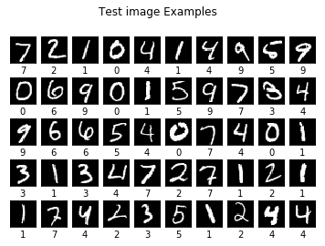

```python
### Bounus 1: show the first 40 images
### ALways a good idea to validate that the data appears as you expect
###
### for sci-kit learn the images are represented as vectors of 784 elements
### currently scaled from 0 to 1

for i in range(50):
    l1_plot = plt.subplot(5, 10, i + 1)
    l1_plot.imshow(255 * X_test[i].reshape(28, 28), interpolation='nearest',
                   cmap=plt.cm.gray)
    l1_plot.set_xticks(())
    l1_plot.set_yticks(())
    #l1_plot.set_xlabel('Class %s' % y_test[i].decode())
    l1_plot.set_xlabel('%i' % int(y_test[i]))
plt.suptitle('Test image Examples')
plt.show()
```

```python
## Data standardization
## by the mean and standared deviation of the training set
scaler = StandardScaler()
X_train = scaler.fit_transform(X_train)
X_test = scaler.transform(X_test)
```

**Comment:**

Standardize features by removing the mean and scaling to unit variance. Centering and scaling happen independently on each feature by computing the relevant statistics on the samples in the training set. Mean and standard deviation are then stored to be used on later data using the transform method.

Standardization of a dataset is a common requirement for most of machine learning estimtors since they might behave badly if the individual features do not look like standard normally distributed data such as Gaussian with mean and unit variance.

The following code can help us to show the images after standardization.

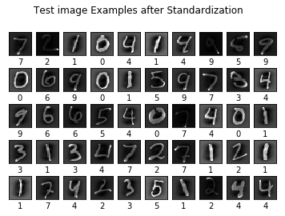

```python
#Show the first forty images after Standardization
for i in range(50):
    l1_plot = plt.subplot(5, 10, i + 1)
    l1_plot.imshow(255 * X_test[i].reshape(28, 28), interpolation='nearest',
                   cmap=plt.cm.gray)
    l1_plot.set_xticks(())
    l1_plot.set_yticks(())
    #l1_plot.set_xlabel('Class %s' % y_test[i].decode())
    l1_plot.set_xlabel('%i' % int(y_test[i]))
plt.suptitle('Test image Examples after Standardization')
plt.show()
```

```python
#train and test classifier
# Turn up tolerance for faster convergence
clf = LogisticRegression(C=50. / 1000,
                         multi_class='multinomial',
                         penalty='l1', solver='saga', tol=0.1)
# Train the classifier
clf.fit(X_train, y_train)

#Evaluate the classifier
sparsity = np.mean(clf.coef_ == 0) * 100
score = clf.score(X_test, y_test)
# print('Best C % .4f' % clf.C_)
print("Sparsity with L1 penalty: %.2f%%" % sparsity)
print("Test score with L1 penalty: %.4f" % score)
```

```
Sparsity with L1 penalty: 17.24%
Test score with L1 penalty: 0.9021
```

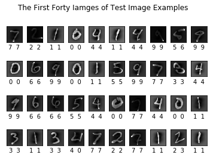

```python
#show the first forty images results
y_predict = clf.predict(X_test)
for i in range(40):
    l1_plot = plt.subplot(4, 10, i + 1)
    plt.subplots_adjust(wspace = .3, hspace = .3)
    l1_plot.imshow(255 * X_test[i].reshape(28, 28), interpolation='nearest',
                   cmap=plt.cm.gray)
    l1_plot.set_xticks(())
    l1_plot.set_yticks(())
    #l1_plot.set_xlabel('Class %s' % y_test[i].decode())
    l1_plot.set_xlabel('%i  %i' % (int(y_test[i]), int(y_predict[i])))
plt.suptitle('The First Forty Iamges of Test Image Examples')
plt.show()
```

**Discussion:**

For this section, we trained the logistic regression classifier using mnist dataset. The first forty images shows above. The labels and the predicted labels show below the images. We can see most of the predicted results are correct since the score of the prediction is 0.9021, which is pretty high. Besides, the recognition results have relationship with how the digits wrote, meaning if a digit wrote commonly and standardedly, it will be easier to recognize correstly.